# Cyclistic Bike-Share Data Analysis

Jason Parker

2023-12-21

## Overview

This was my first data analysis project, completed as one of the capstone projects for the Google Data Analytics Professional Certificate. The background for the project is as follows: Cyclistic is a fictional bike-share company in Chicago, and the director of marketing has concluded that Cyclistic needs to maximize its annual memberships to ensure the company’s future profitability, because annual members are much more profitable than casual riders. The marketing team wants to convert casual riders into annual members, and so the task of this data analysis is to discover important differences between casual riders and annual members (based on historical Cyclistic data), and to provide some recommendations for targeting marketing efforts towards casual riders to encourage them to purchase annual memberships.

The public data for this project is accessible [here](https://divvy-tripdata.s3.amazonaws.com/index.html), and was made available by Motivate International Inc. under this [license](https://divvybikes.com/data-license-agreement).

## Data cleaning and transformation

In this section, I will describe the steps that I took to clean and transform the data in R. I started by loading three of the data tidying packages that I required:

```r
library(tidyverse)
library(lubridate)
library(readr)
```

I then imported the data using the `read_csv` function. For my analysis, I decided to use four quarters of data from a single year, 2019.

```r
q1_2019 <- read_csv("raw_data/Divvy_Trips_2019_Q1.csv")
q2_2019 <- read_csv("raw_data/Divvy_Trips_2019_Q2.csv")
q3_2019 <- read_csv("raw_data/Divvy_Trips_2019_Q3.csv")
q4_2019 <- read_csv("raw_data/Divvy_Trips_2019_Q4.csv")
```

I wanted to combine these four data frames into a single data frame using the `bind_rows` function, but first I needed to make sure that they all had the same number of columns with the same column names.

```r
colnames(q1_2019)
```

```
##  [1] "trip_id"           "start_time"        "end_time"
##  [4] "bikeid"            "tripduration"      "from_station_id"
##  [7] "from_station_name" "to_station_id"     "to_station_name"
## [10] "usertype"          "gender"            "birthyear"
```

```r
colnames(q2_2019)
```

```
##  [1] "01 - Rental Details Rental ID"
##  [2] "01 - Rental Details Local Start Time"
##  [3] "01 - Rental Details Local End Time"
##  [4] "01 - Rental Details Bike ID"
##  [5] "01 - Rental Details Duration In Seconds Uncapped"
##  [6] "03 - Rental Start Station ID"
##  [7] "03 - Rental Start Station Name"
##  [8] "02 - Rental End Station ID"
##  [9] "02 - Rental End Station Name"
## [10] "User Type"
## [11] "Member Gender"
## [12] "05 - Member Details Member Birthday Year"
```

```r
colnames(q3_2019)
```

```
##  [1] "trip_id"           "start_time"        "end_time"
##  [4] "bikeid"            "tripduration"      "from_station_id"
##  [7] "from_station_name" "to_station_id"     "to_station_name"
## [10] "usertype"          "gender"            "birthyear"
```

```r
colnames(q4_2019)
```

```
##  [1] "trip_id"           "start_time"        "end_time"
##  [4] "bikeid"            "tripduration"      "from_station_id"
##  [7] "from_station_name" "to_station_id"     "to_station_name"
## [10] "usertype"          "gender"            "birthyear"
```

`q1_2019`, `q3_2019`, and `q4_2019` all have the same column names, but the column names for `q2_2019` are different. So I had to rename the column names for `q2_2019` so that they are identical to those for the other three data frames.

```r
q2_2019 <- rename(q2_2019,
  trip_id = "01 - Rental Details Rental ID",
  start_time = "01 - Rental Details Local Start Time",
  end_time = "01 - Rental Details Local End Time",
  bikeid = "01 - Rental Details Bike ID",
  tripduration = "01 - Rental Details Duration In Seconds Uncapped",
  from_station_id = "03 - Rental Start Station ID",
  from_station_name = "03 - Rental Start Station Name",
  to_station_id = "02 - Rental End Station ID",
  to_station_name = "02 - Rental End Station Name",
  usertype = "User Type",
  gender = "Member Gender",
  birthyear = "05 - Member Details Member Birthday Year"
)
```

I could then combine the data frames for the four quarters of 2019 into a single data frame for the year 2019.

```r
all_trips <- bind_rows(q1_2019, q2_2019, q3_2019, q4_2019)
```

Next, I inspected the structure of the new data frame `all_trips`.

```r
glimpse(all_trips)
```

```
## Rows: 3,818,004
## Columns: 12
## $ trip_id           <dbl> 21742443, 21742444, 21742445, 21742446, 21742447, 21…
## $ start_time        <dttm> 2019-01-01 00:04:37, 2019-01-01 00:08:13, 2019-01-0…
## $ end_time          <dttm> 2019-01-01 00:11:07, 2019-01-01 00:15:34, 2019-01-0…
## $ bikeid            <dbl> 2167, 4386, 1524, 252, 1170, 2437, 2708, 2796, 6205,…
## $ tripduration      <dbl> 390, 441, 829, 1783, 364, 216, 177, 100, 1727, 336, …
## $ from_station_id   <dbl> 199, 44, 15, 123, 173, 98, 98, 211, 150, 268, 299, 2…
## $ from_station_name <chr> "Wabash Ave & Grand Ave", "State St & Randolph St", …
## $ to_station_id     <dbl> 84, 624, 644, 176, 35, 49, 49, 142, 148, 141, 295, 4…
## $ to_station_name   <chr> "Milwaukee Ave & Grand Ave", "Dearborn St & Van Bure…
## $ usertype          <chr> "Subscriber", "Subscriber", "Subscriber", "Subscribe…
## $ gender            <chr> "Male", "Female", "Female", "Male", "Male", "Female"…
## $ birthyear         <dbl> 1989, 1990, 1994, 1993, 1994, 1983, 1984, 1990, 1995…
```

I then started to clean the data. First, I checked whether there were any duplicate values in the `trip_id` column, because all of the values in this column should be distinct:

```r
sum(duplicated(all_trips$trip_id)) # count the number of duplicate values in the trip_id column
```

```
## [1] 0
```

There are no duplicate values in the `trip_id` column, so the `all_trips` data frame does not have any duplicate rows. Next, I looked at the distinct values in the `gender` and `usertype` columns, to make sure that neither column had values that were formatted or inserted incorrectly:

```r
unique(all_trips$gender)
```

```
## [1] "Male"   "Female" NA
```

```r
unique(all_trips$usertype)
```

```
## [1] "Subscriber" "Customer"
```

The distinct values in the `gender` column are “Male”, “Female”, and “NA”; the first two make sense, while any rows with an “NA” value in the `gender` column will be removed below. The only two user types are “Subscriber” and “Customer”, which I needed to rename to (respectively) “Member” and “Casual”.

```r
all_trips <- all_trips %>% mutate(usertype = recode(usertype, "Subscriber" = "Member", "Customer" = "Casual"))
```

I then removed any rows that contained null values.

```r
all_trips <- all_trips %>% drop_na()
```

I then examined the birth years, to ensure that they made sense.

```r
unique(all_trips$birthyear)
```

```
##  [1] 1989 1990 1994 1993 1983 1984 1995 1996 1986 1967 1985 1957 1959 1991 1961
## [16] 1968 1964 1988 1976 1992 1979 1952 1980 1974 1977 1971 1987 1981 1982 1969
## [31] 1962 1975 1954 1972 1997 1951 1998 1965 1947 1946 1966 1956 1978 1973 1950
## [46] 1960 1955 1958 1999 1970 2002 1948 1940 1963 1953 2000 1942 1945 1939 2001
## [61] 1918 1949 1900 1934 2003 1921 1944 1933 1943 1941 1938 1931 1909 2014 1930
## [76] 1912 1936 1759 1790 1901 1905 1929 1904 1935 1899 1889 1920 1925 1937
```

There are 89 different birth years in the data, but some of them do not make sense for the year 2019: 1900, 1909, 1759, 1790, 1901, 1905, 1904, 1899, 1889. I first found out how many rides had a birth year before 1910 (making the rider at least 110 years old, which is very unlikely):

```r
sum(all_trips$birthyear < 1910)
```

```
## [1] 678
```

There are 678 rides with a birth year before 1910, so I decided to remove these rows, because the birth year was likely input incorrectly.

```r
all_trips <- all_trips %>% filter(birthyear >= 1910)
```

I then wanted to verify that the `tripduration` column actually computed the difference (in seconds) between the start and end time for each ride:

```r
sum(all_trips$tripduration == difftime(all_trips$end_time,all_trips$start_time, units="secs"))
```

```
## [1] 2307800
```

There are (only) 2,307,800 rows where the `tripduration` column is equal to the time difference in seconds between the start and end times, which suggests that almost one million rows do not have the correct trip duration value. So I decided to drop the `tripduration` column and then create a new, correct column for trip duration.

```r
all_trips <- all_trips %>% select(-tripduration)

all_trips <- all_trips %>%
  mutate(
  trip_duration = difftime(all_trips$end_time,all_trips$start_time, units="secs"), .after=end_time
  )
```

I then converted the trip duration to numeric, so that I could run calculations on that data.

```r
is.numeric(all_trips$trip_duration)
```

```
## [1] FALSE
```

```r
all_trips$trip_duration <- as.numeric(as.character(all_trips$trip_duration))

is.numeric(all_trips$trip_duration)
```

```
## [1] TRUE
```

I then summarized the data in the new `trip_duration` column.

```r
summary(all_trips$trip_duration)
```

```
##    Min. 1st Qu.  Median    Mean 3rd Qu.    Max.
##   -3382     380     631    1071    1076 9056634
```

The minimum trip duration is negative, and the maximum is over 9 million seconds (104 days). I then removed all of the rides with negative trip durations:

```r
all_trips <- all_trips %>% filter(trip_duration > 0)
```

Currently I could only aggregate the ride data based on the ride level, which is too granular. So I decided to add some additional columns for the date, month, and day of each ride.

```r
all_trips <- all_trips %>%
  mutate(
    date = as.Date(all_trips$start_time),
    month = format(as.Date(date), "%m"),
    day = format(as.Date(date), "%d"),
    day_of_week = format(as.Date(date), "%A"))
```

I then added a column that calculates the (approximate) age in 2019 for each rider:

```r
all_trips <- all_trips %>%
  mutate(age = 2019 - birthyear)
```

Next, I added a column that records the approximate season (fall, winter, spring, summer) in which each ride occurred.

```r
all_trips <- all_trips %>%
  mutate(
    season = case_when(
      month %in% c("12", "01", "02") ~ "winter",
      month %in% c("03", "04", "05") ~ "spring",
      month %in% c("06", "07", "08") ~ "summer",
      month %in% c("09", "10", "11") ~ "fall"
    )
  )
```

I then added a column to check if each ride was a round trip, i.e. whether the rider returned the bike back to the starting location (1 if yes, 0 if no).

```r
all_trips <- all_trips %>%
  mutate(round_trip = if_else(from_station_id == to_station_id, 1, 0))
```

I then added a column for the (starting) time of each ride, so that I could then add a column for the approximate time of day of each ride (early morning, morning, afternoon, evening).

```r
all_trips <- all_trips %>%
  mutate(time = format(start_time, format="%H:%M:%S"))

all_trips <- all_trips %>%
  mutate(
    time_of_day = case_when(
      "00:00:00" <= all_trips$time & all_trips$time <= "06:00:00"  ~ "early morning",
      "06:00:00" < all_trips$time & all_trips$time <= "12:00:00"  ~ "morning",
      "12:00:00" < all_trips$time & all_trips$time <= "18:00:00"  ~ "afternoon",
      "18:00:00" < all_trips$time & all_trips$time <= "23:59:59"  ~ "evening"
    )
  )
```

Finally, I added a column that checks whether a ride occurred on a weekday or on the weekend.

```r
all_trips <- all_trips %>%
  mutate(
    time_of_week = ifelse(day_of_week %in% c("Saturday", "Sunday"), "weekend", "weekday")
  )
```

This completed my data cleaning and transformation process. Next, I analyzed the data to determine how annual members and casual riders use Cyclistic bikes differently. First, here’s a glimpse of the final cleaned and transformed data frame `all_trips`:

```r
glimpse(all_trips)
```

```
## Rows: 3,258,110
## Columns: 22
## $ trip_id           <dbl> 21742443, 21742444, 21742445, 21742446, 21742447, 21…
## $ start_time        <dttm> 2019-01-01 00:04:37, 2019-01-01 00:08:13, 2019-01-0…
## $ end_time          <dttm> 2019-01-01 00:11:07, 2019-01-01 00:15:34, 2019-01-0…
## $ trip_duration     <dbl> 390, 441, 829, 1783, 364, 216, 177, 100, 1727, 336, …
## $ bikeid            <dbl> 2167, 4386, 1524, 252, 1170, 2437, 2708, 2796, 6205,…
## $ from_station_id   <dbl> 199, 44, 15, 123, 173, 98, 98, 211, 150, 268, 299, 2…
## $ from_station_name <chr> "Wabash Ave & Grand Ave", "State St & Randolph St", …
## $ to_station_id     <dbl> 84, 624, 644, 176, 35, 49, 49, 142, 148, 141, 295, 4…
## $ to_station_name   <chr> "Milwaukee Ave & Grand Ave", "Dearborn St & Van Bure…
## $ usertype          <chr> "Member", "Member", "Member", "Member", "Member", "M…
## $ gender            <chr> "Male", "Female", "Female", "Male", "Male", "Female"…
## $ birthyear         <dbl> 1989, 1990, 1994, 1993, 1994, 1983, 1984, 1990, 1995…
## $ date              <date> 2019-01-01, 2019-01-01, 2019-01-01, 2019-01-01, 201…
## $ month             <chr> "01", "01", "01", "01", "01", "01", "01", "01", "01"…
## $ day               <chr> "01", "01", "01", "01", "01", "01", "01", "01", "01"…
## $ day_of_week       <chr> "Tuesday", "Tuesday", "Tuesday", "Tuesday", "Tuesday…
## $ age               <dbl> 30, 29, 25, 26, 25, 36, 35, 29, 24, 23, 25, 25, 33, …
## $ season            <chr> "winter", "winter", "winter", "winter", "winter", "w…
## $ round_trip        <dbl> 0, 0, 0, 0, 0, 0, 0, 0, 0, 0, 0, 0, 0, 0, 0, 0, 0, 0…
## $ time              <chr> "00:04:37", "00:08:13", "00:13:23", "00:13:45", "00:…
## $ time_of_day       <chr> "early morning", "early morning", "early morning", "…
## $ time_of_week      <chr> "weekday", "weekday", "weekday", "weekday", "weekday…
```

## Analysis of the data

First, I decided to compare annual members and casual riders with respect to total number of rides, average and median ride lengths, most popular day of the week for rides, average and median ages of riders, most common age of riders, and most popular month, season, time of day, and time of week of rides:

```r
library(DescTools) # I needed to load the DescTools package to use the Mode() function.

all_trips %>%
  group_by(usertype) %>%
  summarize(
    number_of_rides = n(),
    average_ride_length = mean(trip_duration),
    median_ride_length = median(trip_duration),
    most_popular_day = Mode(day_of_week),
    average_age = mean(age),
    median_age = median(age),
    mode_age = Mode(age),
    most_popular_month = Mode(month),
    most_popular_season = Mode(season),
    most_popular_time_of_day = Mode(time_of_day),
    most_popular_time_of_week = Mode(time_of_week),
  ) %>%
  glimpse()
```

```
## Rows: 2
## Columns: 12
## $ usertype                  <chr> "Casual", "Member"
## $ number_of_rides           <int> 344154, 2913956
## $ average_ride_length       <dbl> 2869.4999, 858.7227
## $ median_ride_length        <dbl> 1386, 588
## $ most_popular_day          <chr> "Saturday", "Tuesday"
## $ average_age               <dbl> 30.94159, 35.36693
## $ median_age                <dbl> 28, 32
## $ mode_age                  <dbl> 25, 27
## $ most_popular_month        <chr> "08", "08"
## $ most_popular_season       <chr> "summer", "summer"
## $ most_popular_time_of_day  <chr> "afternoon", "afternoon"
## $ most_popular_time_of_week <chr> "weekday", "weekday"
```

The average and median ride lengths are much longer for casual riders vs. annual members: for casual riders, the average and median ride lengths are respectively 2869 and 1386 seconds, while for annual members they are respectively 859 and 588 seconds. Also, the most popular day of the week for casual riders is Saturday, while for annual members it is Tuesday. Casual riders are also younger (on average) than annual members: the average and median ages for casual riders are respectively 30.9 and 28, while those for annual members are respectively 35.4 and 32 (also, the most common age for casual riders is 25, while for annual members it is 27). For both kinds of riders, the most popular riding season is the summer (specifically, the month of August), the most popular time of day for a ride is the afternoon, and the most popular time of the week for a ride is on a weekday (as opposed to the weekend). Annual members also took far more total rides: 2,913,956 for annual members vs. only 344,154 for casual riders.

I noticed that the days of the week are out of order, so I fixed that.

```r
all_trips$day_of_week <- ordered(all_trips$day_of_week, levels=c("Sunday", "Monday",
                                                                       "Tuesday", "Wednesday", "Thursday", "Friday", "Saturday"))
```

Next, I compared annual members and casual riders by day of the week, with respect to the total number of rides, average ride length, and most popular month, season, and time of day for a ride:

```r
all_trips %>%
  group_by(usertype, day_of_week) %>%
  summarize(
    number_of_rides = n(),
    average_ride_length = mean(trip_duration),
    most_popular_month = Mode(month),
    most_popular_season = Mode(season),
    most_popular_time_of_day = Mode(time_of_day),
  ) %>%
  arrange(usertype, day_of_week) %>%
  glimpse()
```

```
## Rows: 14
## Columns: 7
## Groups: usertype [2]
## $ usertype                 <chr> "Casual", "Casual", "Casual", "Casual", "Casu…
## $ day_of_week              <ord> Sunday, Monday, Tuesday, Wednesday, Thursday,…
## $ number_of_rides          <int> 63522, 40656, 36396, 36768, 41113, 47114, 785…
## $ average_ride_length      <dbl> 2931.7112, 3039.3840, 3009.4342, 2576.4930, 2…
## $ most_popular_month       <chr> "08", "09", "07", "07", "08", "08", "08", "08…
## $ most_popular_season      <chr> "summer", "summer", "summer", "summer", "summ…
## $ most_popular_time_of_day <chr> "afternoon", "afternoon", "afternoon", "after…
```

Next, I wanted to calculate the gender proportions of casual riders vs. annual members.

```r
all_trips %>%
  group_by(usertype) %>%
  summarize(
    percent_male_trips = sum(gender == 'Male')/n(),
    percent_female_trips = sum(gender == 'Female')/n(),
  ) %>%
  print()
```

```
## # A tibble: 2 × 3
##   usertype percent_male_trips percent_female_trips
##   <chr>                 <dbl>                <dbl>
## 1 Casual                0.618                0.382
## 2 Member                0.751                0.249
```

Of the casual rider trips, 61.8% were male and 38.2% were female, while of the annual member trips, 75.1% were male and 24.9% were female. So annual members seem to have a greater proportion of males than casual riders.

I then wanted to calculate what proportion of the casual vs. annual rides were round trips, i.e. rides where the rider returned the bike to the same location from which they started.

```r
all_trips %>%
  group_by(usertype) %>%
  summarize(
    percent_round_trips = sum(round_trip)/n()
  ) %>%
  print()
```

```
## # A tibble: 2 × 2
##   usertype percent_round_trips
##   <chr>                  <dbl>
## 1 Casual                0.0845
## 2 Member                0.0160
```

So 8.45% of the casual rider trips were round trips, whereas only 1.6% of the annual member trips were round trips.

## Visualizations

I now visualized some of these salient differences between casual riders and annual members.

First, I visualized the difference in average ride length (in minutes) by day of the week, in a clustered column chart.

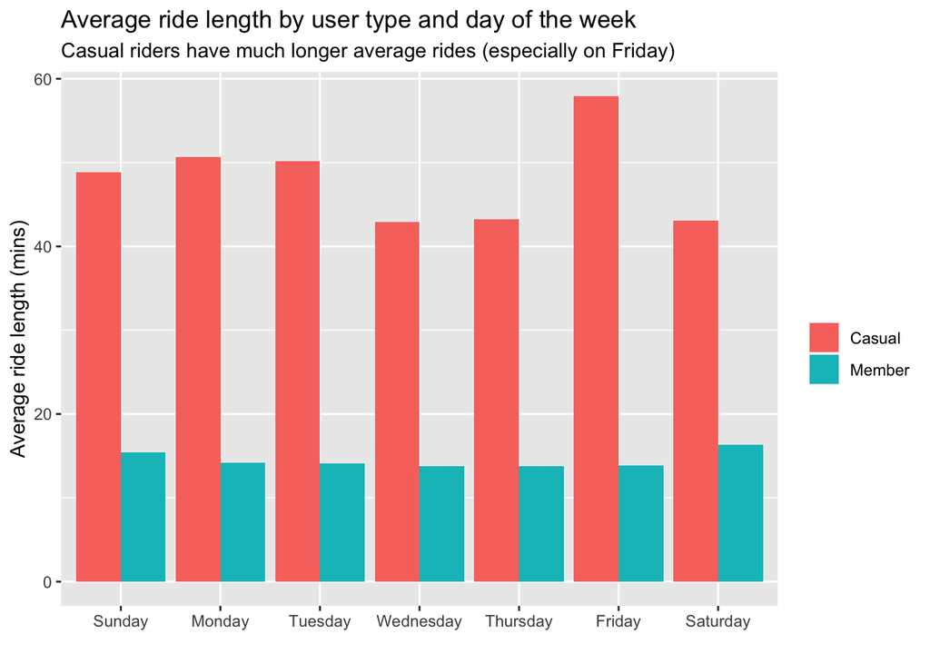

```r
all_trips %>%
  group_by(usertype, day_of_week) %>%
  summarize(
    average_ride_length = mean(trip_duration),
    avg_ride_length_mins = average_ride_length/60
  ) %>%
  arrange(usertype, day_of_week) %>%
  ggplot() +
  geom_col(mapping = aes(x = day_of_week, y = avg_ride_length_mins, fill = usertype), position = "dodge") +
  labs(
    title = "Average ride length by user type and day of the week",
    subtitle = "Casual riders have much longer average rides (especially on Friday)",
    x = " ",
    y = "Average ride length (mins)",
    fill = " "
  )
```

Then I visualized the differences in numbers of rides by day of the week, again in a clustered column chart.

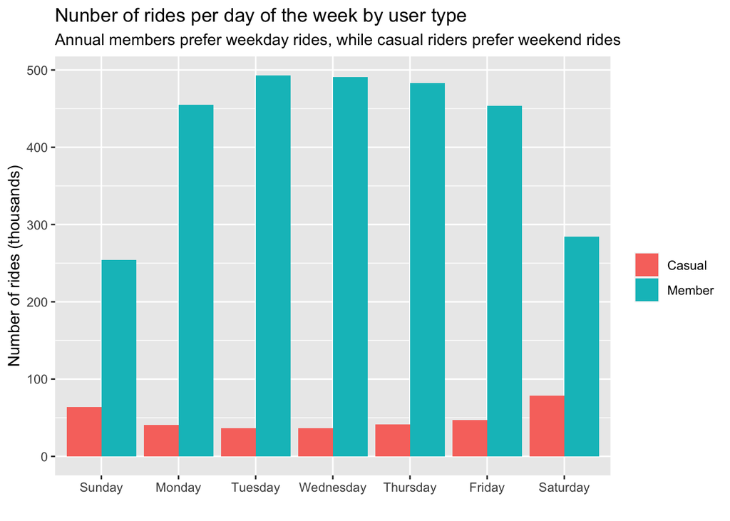

```r
all_trips %>%
  group_by(usertype, day_of_week) %>%
  summarize(
    number_of_rides = n(),
  ) %>%
  ggplot() +
  geom_col(mapping = aes(x = day_of_week, y = number_of_rides/1000, fill = usertype), position = "dodge") +
  labs(
    title = "Nunber of rides per day of the week by user type",
    subtitle = "Annual members prefer weekday rides, while casual riders prefer weekend rides",
    x = " ",
    y = "Number of rides (thousands)",
    fill = " "
  )
```

Lastly, I visualized the gender proportions by user type, in a 100% stacked column chart.

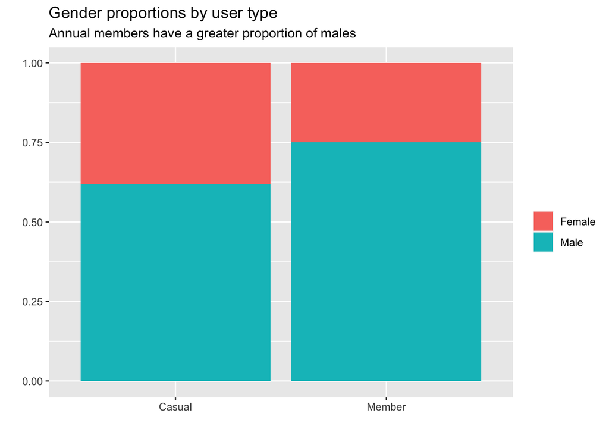

```r
ggplot(all_trips) +
  geom_bar(mapping = aes(x = usertype, fill = gender), position = "fill") +
  labs(
    title = "Gender proportions by user type",
    subtitle = "Annual members have a greater proportion of males",
    x = " ",
    y = " ",
    fill = " "
  )
```

## Recommendations

Based on my analysis of the Cyclistic ride data for 2019, here are my top three recommendations (in no particular order) for how the Cyclistic marketing team can best attempt to convert more casual riders into annual members:

- Casual riders trend younger than annual members and have a more balanced gender breakdown, so marketing efforts to convert casual riders into annual members should be targeted towards a younger and more gender-balanced audience.
- Casual riders prefer to ride on the weekend, so a marketing strategy to convince casual riders to purchase an annual membership might involve offering a discount on the annual membership fee if a majority of rides are taken on the weekend.
- Casual riders take much longer rides on average, so a marketing strategy to convince casual riders to become annual members might involve offering a discount on the annual membership fee if a majority of the rides taken are longer than a certain time threshold.